# Logistic and Poisson Regression

Published

October 14, 2025

### Bayes’ Theorem

Bayes’ theorem is a theorem of conditional probability formulated using other probability definitions.

Given event *A* and event *B*, the probability of *A* and *P* can be re-written as a conditional probability.

$$P(A \hspace{1mm} and \hspace{1mm} B) = P(A|B)P(B) = P(B|A)P(A)$$

We can thus set these two conditional probabilities equal to each other and get that

$$P(A|B) = \frac{P(B|A)P(A)}{P(B)}$$

### When do we use Bayes’ Theorem?

Bayes’ theorem has been revolutionary in the field of statistics. Given evidence (or data) *X* and parameters $\theta$, the above theorem is often written in the form

$$P(\theta|X) = \frac{P(X|\theta)P(\theta)}{P(X)}$$

Where $P(\theta|X)$ can be viewed as the probability of the parameters given the data. In Bayesian statistics, it is also known as the **posterior distribution.** $P(X|\theta)$ is known as the **likelihood** (the probability of the data given the parameters) and $P(\theta)$ is known as the **prior.** $P(X)$ is often known as the normalizing constant and thanks to the total law of probability, can be written as $\int P(X|\theta)P(\theta)d\theta$. However, this is often very hard to find, and is also a constant, so often one will see that

$$P(\theta|X) \propto P(X|\theta)P(\theta)$$

Where $\propto$ means ‘’proportional to.’’ Usually, $P(\theta)$ will be set beforehand based on prior knowledge. Or it will be set to a neutral condition to signify no additional knowledge. And then $P(X|\theta)$ can be calculated using maximum likelihood, which is where we calculate the most likely parameter $\theta$. See my blog post on maximum likelihood [here](https://drodriguezchavez.github.io/stat-blog/maximum-likelihood.html).

### Generalized Linear Models

### Poisson Regression

Poisson regression deals with count data.

$$\begin{align}
Y \sim Poisson(\lambda) \\
log(\lambda) = \beta_0 + \beta_1 X
\end{align}$$

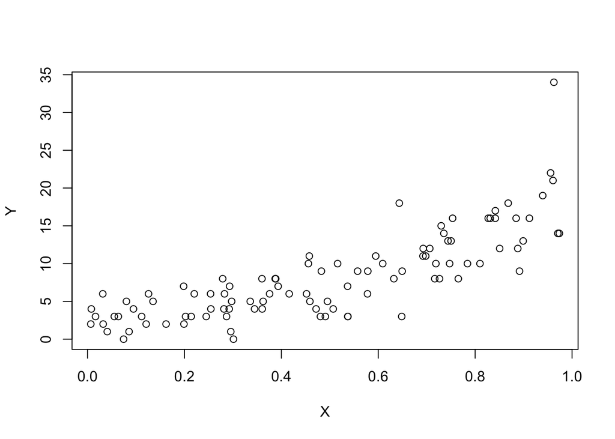

```r
# setting up our model parameters
N <- 100
beta0 <- 1
beta1 <- 2
X <- runif(N, 0, 1)
lambda <- exp(beta0 + beta1 * X)

# getting our observations
Y <- rpois(N, lambda = lambda)

# plotting
plot(Y ~ X)
```

### How do we estimate these parameters?

First let’s take a look at the Poisson distribution:

$$P(Y | \lambda) = \frac{e^{-\lambda} \lambda^y}{y!}$$
In maximum likelihood, we have assumed that our data is independent and each point is coming from a Poisson distribution. The probability of the exact realization of our data is the same as multiplying the probability mass function of each data point together.
$$\mathcal{L}(\lambda | Y) = P(Y = y_i | \lambda) = \Pi_{i=1}^n \frac{ \lambda^{y_i} }{y_i !} e^{- \lambda}$$
This is known as our **likelihood function**. We want to find $\lambda$ that maximizes this function. *Note that to make this calculation easier, and because we are assuming there is one maximum, we usually use the log-likelihood instead.*

$$\begin{align}
\text{ln} \hspace{1mm} \mathcal{L}(\lambda | Y) &= \sum_1^n (y_i*log(\lambda) +log(e^{-\lambda}) - log(y_i!))
\\
&= \sum_1^n (y_i*log(\lambda) -\lambda - log(y_i!))
\end{align}$$
However, let’s first re-write this in terms of linear model. We have defined our $y_i$’s to come from a Poisson distribution where $\lambda = e^{(\beta_0 + \beta_1 * x_i)}$. Thus we have that

$$\begin{align}
\text{ln} \hspace{1mm} \mathcal{L}(\lambda | Y) &= \sum_1^n (y_i*log(\lambda) -\lambda - log(y_i!))
\\ &= \sum_1^n (y_i*log(e^{(\beta_0 + \beta_1 * x_i)}) -e^{(\beta_0 + \beta_1 * x_i)} - log(y_i!))
\\ &= \sum_1^n (y_i*(\beta_0 + \beta_1 * x_i) -e^{(\beta_0 + \beta_1 * x_i)} - log(y_i!))
\end{align}$$
To maximize a function, one takes the derivative, sets the function equal to 0, and solves. However instead of trying to take the derivative of this two-dimensional system (because $\lambda$ is a function of both $\beta_0$ and $\beta_1$), we can use the optim function in r. *Note that the optim function takes in a function and minimizes it.*

```r
# creating our log-likelihood function
llh <- function(theta) {
  b0 <- theta[1]
  b1 <- theta[2]
  -(sum(Y*(b0 + b1*X)) - sum(exp(b0+b1*X)) - sum(log(factorial(Y)))) # we negate it to get the maximum
}

llh.estimates <- optim(c(1,1), llh, hessian = T)
llh.estimates$par
```

```
[1] 0.9179312 2.0760536
```

These are our estimates, otherwise known as our **maximum likelihood estimates (MLEs)**.

### What about our standard errors?

In regular linear regression, our standard errors were found.

In textbooks it is common to see that $\hat{\theta} \sim N(\theta, I^{-1}(\theta))$, where $I(\theta)$ is what is known as the information matrix and is the negative of the Hessian matrix evaluated at our MLEs. The Hessian is the matrix of second-order partial derivatives and intuitively we can think of them as the curvature of the function. If our likelihood function gives us a surface (where we have $\beta_0$ and $\beta_1$ as the x-y axis and the output of the log-likelihood as the z-axis), then the Hessian gives us the curvature at each point on this surface.

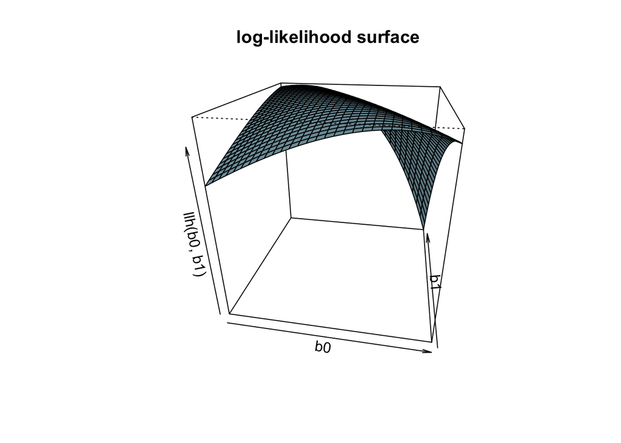

```r
b0 <- seq(0, 2, length = 30)
b1 <- seq(1, 3, length = 30)

llh_grid <- function(b0, b1) {
  llh(c(b0, b1))
}

# Create a grid matrix
z <- outer(b0, b1, Vectorize(llh_grid))

# Draw the 3D surface
persp(b0, b1, -z,
      theta = 10, phi = 25,      # viewing angles
      col = "lightblue",         # surface color
      shade = 0.5,               # shading intensity
      xlab = 'b0', ylab = 'b1', zlab = "llh(b0, b1)",
      main = "log-likelihood surface")
```

We can construct our Hessian from our log-likelihood:

```r
hessian <- function(b0, b1) {
  matrix(c( -sum(exp(b0 + b1*x)) , -sum(x*exp(b0+b1*x)),
           -sum(x*exp(b0+b1*x)) , -sum(x^2*exp(b0+b1*x)) ),
         nrow = 2, byrow = T)
}
```

```r
llh.estimates$hessian
```

```
         [,1]     [,2]
[1,] 816.9232 527.8137
[2,] 527.8137 395.7976
```

```r
fit <- glm(Y ~ X, family=poisson)
summary(fit)
```

```
Call:
glm(formula = Y ~ X, family = poisson)

Coefficients:
            Estimate Std. Error z value Pr(>|z|)
(Intercept)  0.91810    0.09404   9.763   <2e-16 ***
X            2.07594    0.13511  15.365   <2e-16 ***
---
Signif. codes:  0 '***' 0.001 '**' 0.01 '*' 0.05 '.' 0.1 ' ' 1

(Dispersion parameter for poisson family taken to be 1)

    Null deviance: 373.51  on 99  degrees of freedom
Residual deviance: 113.90  on 98  degrees of freedom
AIC: 486.13

Number of Fisher Scoring iterations: 4
```

### Additional Resources

- Great introductory video on generalized linear models: https://www.youtube.com/watch?v=1fZeBafD1nw
- Great video on Logistic Regression: https://www.youtube.com/watch?v=Iju8l2qgaJU